# README

D Thomas

July 2, 2017

# Case Study : Sample Beer Study

## Author: D. Thomas, Section 405

### Introduction:

The Sample Beer Case Study is designed and developed to understand and shed light on the relationship or correlation, if any, of the two variables IBU vs. ABV, that is, International Bitterness Units of a certain Beer vs. Alcohol by Volume of the certain Beer. This Study samples from various Breweries throughout the United States.

### File Organization:

Resembles the following Model:

- Modifications
- Additional Docs

### Questions:

#### 1. How many Breweries are present in each state?

```
## Classes 'tbl_df', 'tbl' and 'data.frame':    558 obs. of  4 variables:
##  $ Brew_ID: int  1 2 3 4 5 6 7 8 9 10 ...
##  $ Name   : chr  "NorthGate Brewing" "Against the Grain Brewery" "Jack's Abby Craft Lagers" "Mike Hess Brewing Company" ...
##  $ City   : chr  "Minneapolis" "Louisville" "Framingham" "San Diego" ...
##  $ State  : chr  "MN" "KY" "MA" "CA" ...
##  - attr(*, "spec")=List of 2
##   ..$ cols   :List of 4
##   .. ..$ Brew_ID: list()
##   .. .. ..- attr(*, "class")= chr  "collector_integer" "collector"
##   .. ..$ Name   : list()
##   .. .. ..- attr(*, "class")= chr  "collector_character" "collector"
##   .. ..$ City   : list()
##   .. .. ..- attr(*, "class")= chr  "collector_character" "collector"
##   .. ..$ State  : list()
##   .. .. ..- attr(*, "class")= chr  "collector_character" "collector"
##   ..$ default: list()
##   .. ..- attr(*, "class")= chr  "collector_guess" "collector"
##   ..- attr(*, "class")= chr "col_spec"
```

```
##
## AK AL AR AZ CA CO CT DC DE FL GA HI IA ID IL IN KS KY LA MA MD ME MI MN MO
##  7  3  2 11 39 47  8  1  2 15  7  4  5  5 18 22  3  4  5 23  7  9 32 12  9
## MS MT NC ND NE NH NJ NM NV NY OH OK OR PA RI SC SD TN TX UT VA VT WA WI WV
##  2  9 19  1  5  3  3  4  2 16 15  6 29 25  5  4  1  3 28  4 16 10 23 20  1
## WY
##  4
```

The table(Breweries$State) command gives the values of Breweries in each State

#### 2. Merge beer data with breweries data by Breweryid. Print first 6 observations and the last six observations to check the merged file.

```
##   Brew_ID        Name.x Beer_ID   ABV IBU
## 1       1  Get Together    2692 0.045  50
## 2       1 Maggie's Leap    2691 0.049  26
## 3       1    Wall's End    2690 0.048  19
## 4       1       Pumpion    2689 0.060  38
## 5       1    Stronghold    2688 0.060  25
## 6       1   Parapet ESB    2687 0.056  47
##                                 Style Ounces            Name.y        City
## 1                        American IPA     16 NorthGate Brewing Minneapolis
## 2                  Milk / Sweet Stout     16 NorthGate Brewing Minneapolis
## 3                   English Brown Ale     16 NorthGate Brewing Minneapolis
## 4                         Pumpkin Ale     16 NorthGate Brewing Minneapolis
## 5                     American Porter     16 NorthGate Brewing Minneapolis
## 6 Extra Special / Strong Bitter (ESB)     16 NorthGate Brewing Minneapolis
##   State
## 1    MN
## 2    MN
## 3    MN
## 4    MN
## 5    MN
## 6    MN
```

```
##      Brew_ID                    Name.x Beer_ID   ABV IBU
## 2405     556             Pilsner Ukiah      98 0.055  NA
## 2406     557  Heinnieweisse Weissebier      52 0.049  NA
## 2407     557           Snapperhead IPA      51 0.068  NA
## 2408     557         Moo Thunder Stout      50 0.049  NA
## 2409     557         Porkslap Pale Ale      49 0.043  NA
## 2410     558 Urban Wilderness Pale Ale      30 0.049  NA
##                        Style Ounces                        Name.y
## 2405         German Pilsener     12         Ukiah Brewing Company
## 2406              Hefeweizen     12       Butternuts Beer and Ale
## 2407            American IPA     12       Butternuts Beer and Ale
## 2408      Milk / Sweet Stout     12       Butternuts Beer and Ale
## 2409 American Pale Ale (APA)     12       Butternuts Beer and Ale
## 2410        English Pale Ale     12 Sleeping Lady Brewing Company
##               City State
## 2405         Ukiah    CA
## 2406 Garrattsville    NY
## 2407 Garrattsville    NY
## 2408 Garrattsville    NY
## 2409 Garrattsville    NY
## 2410     Anchorage    AK
```

#### 3. Report the number of NA’s in each column.

```
##     Brew_ID         Name.x             Beer_ID            ABV
##  Min.   :  1.0   Length:2410        Min.   :   1.0   Min.   :0.00100
##  1st Qu.: 94.0   Class :character   1st Qu.: 808.2   1st Qu.:0.05000
##  Median :206.0   Mode  :character   Median :1453.5   Median :0.05600
##  Mean   :232.7                      Mean   :1431.1   Mean   :0.05977
##  3rd Qu.:367.0                      3rd Qu.:2075.8   3rd Qu.:0.06700
##  Max.   :558.0                      Max.   :2692.0   Max.   :0.12800
##                                                      NA's   :62
##       IBU            Style               Ounces         Name.y
##  Min.   :  4.00   Length:2410        Min.   : 8.40   Length:2410
##  1st Qu.: 21.00   Class :character   1st Qu.:12.00   Class :character
##  Median : 35.00   Mode  :character   Median :12.00   Mode  :character
##  Mean   : 42.71                      Mean   :13.59
##  3rd Qu.: 64.00                      3rd Qu.:16.00
##  Max.   :138.00                      Max.   :32.00
##  NA's   :1005
##      City              State
##  Length:2410        Length:2410
##  Class :character   Class :character
##  Mode  :character   Mode  :character
##
##
##
##
```

We see that two columns have NA’s ABV and IBU, which is 62 and 1005 respectively.

#### 4. Compute the median alcohol content and international bitterness unit for each state. Plot a bar graph to compare.

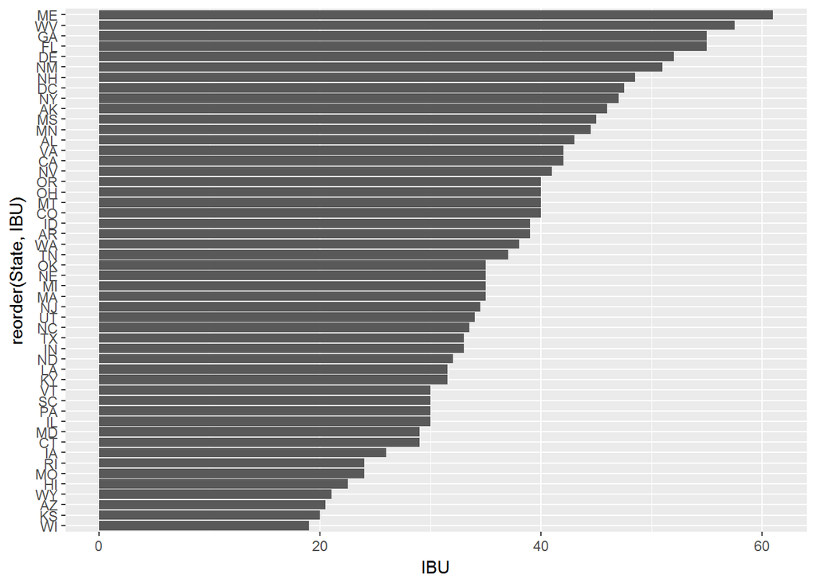

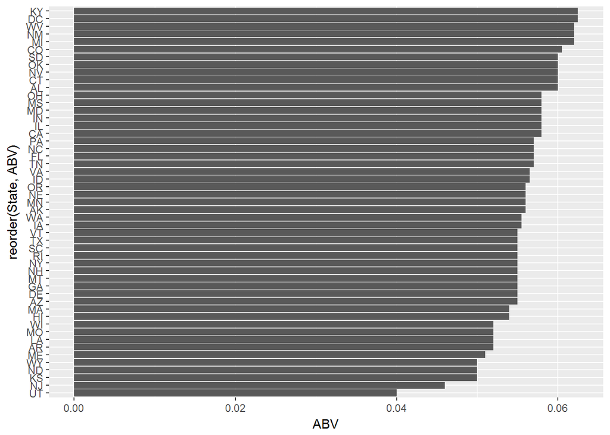

Here are the Charts:

#### 5. Which state has the maximum alcoholic beer? Which stae has the most bitter beer?

```
## [1] "CO"
```

```
## [1] 0.128
```

```
## [1] "OR"
```

```
## [1] 138
```

#### 6. Summary statistics for ABV (Alcohol by volume) variable.

```
##    Min. 1st Qu.  Median    Mean 3rd Qu.    Max.    NA's
## 0.00100 0.05000 0.05600 0.05977 0.06700 0.12800      62
```

#### 7. Is there a relationship between the bitterness of the beer and its alcoholic content? Draw a scatter plot?

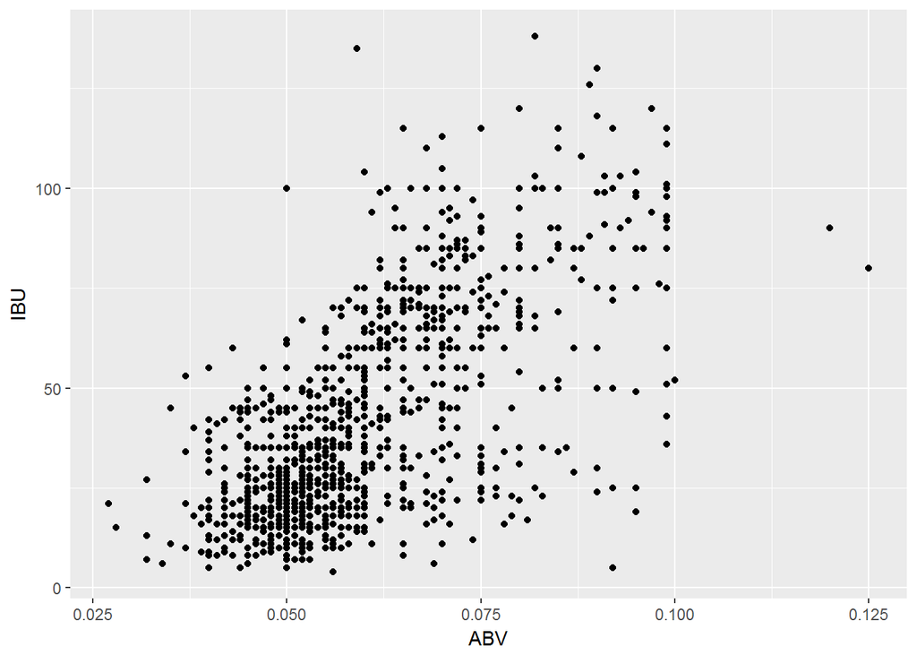

```
##
##  Pearson's product-moment correlation
##
## data:  BrewBeers$ABV and BrewBeers$IBU
## t = 33.863, df = 1403, p-value < 2.2e-16
## alternative hypothesis: true correlation is not equal to 0
## 95 percent confidence interval:
##  0.6407982 0.6984238
## sample estimates:
##       cor
## 0.6706215
```

This result shows a moderatly postive correlation between the two variables IBU and ABV.